# Untitled

Bela Koch

2024-03-14

## Prepare data / feature engineering

```r
data <- read_data()

data$appartment_collateral_mv <- ifelse(
  data$real_estate_type == "appartment",
  data$mortgage_collateral_mv,
  0
)
data$house_collateral_mv <- ifelse(
  data$real_estate_type == "single family house",
  data$mortgage_collateral_mv,
  0
)
data$office_collateral_mv <- ifelse(
  data$real_estate_type == "office building",
  data$mortgage_collateral_mv,
  0
)
data$single_family_house <- ifelse(
  data$real_estate_type == "single family house",
  1,
  0
)
data$lgd_nom <- data$lgd * data$loan_amount
data$office_collateral_ratio <- data$office_collateral_mv / data$loan_amount
data$additional_collateral_ratio <- data$additional_collateral_mv / data$loan_amount
```

## Segment 1: Private Clients

Note that the observed loss given default seems to depend on the type of real estate:

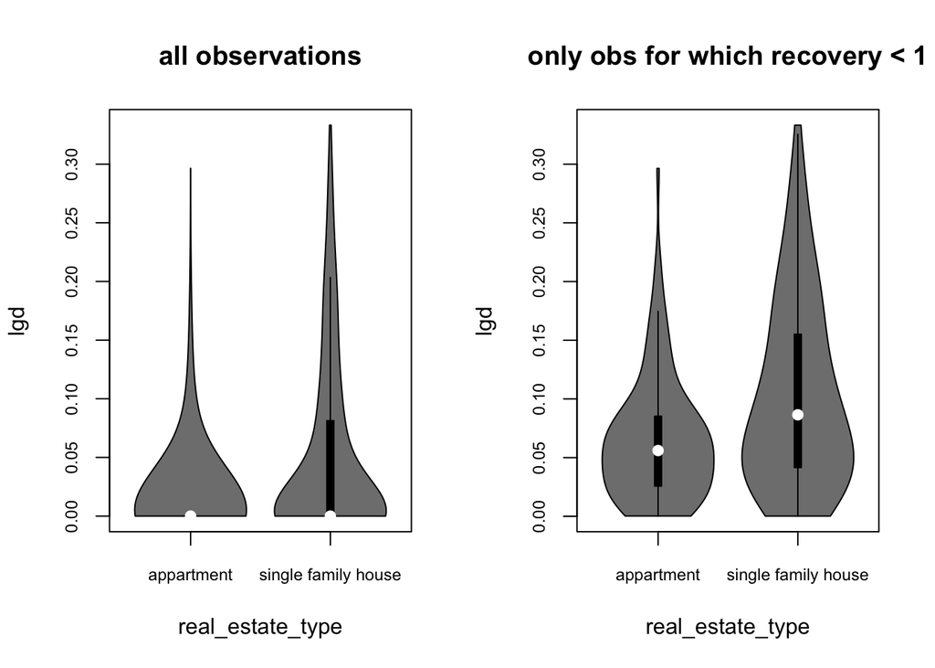

Economic intuition: selling conditions for real estate might differ across real estate types. Single family houses might to be more difficult to sell - or more generally can be sold in case of default with a higher loss.

For this reason, the market value per real estate type is treated differently, i.e. for each real estate category one column is added containing the market value if the corresponding contract is on the given real estate type and zero otherwise, same of additional collateral:

|  | real_estate_type | house_collateral_mv | appartment_collateral_mv |
| --- | --- | --- | --- |
| 736 | single family house | 1636145 | 0.0 |
| 827 | single family house | 1766339 | 0.0 |
| 719 | single family house | 1521278 | 0.0 |
| 274 | appartment | 0 | 1444293.6 |
| 648 | single family house | 1784238 | 0.0 |
| 519 | appartment | 0 | 920868.9 |

Remember that the models are fitted using nominal values. Therefore, the higher the collateral value the higher the expected loss given default (ceteris paribus):

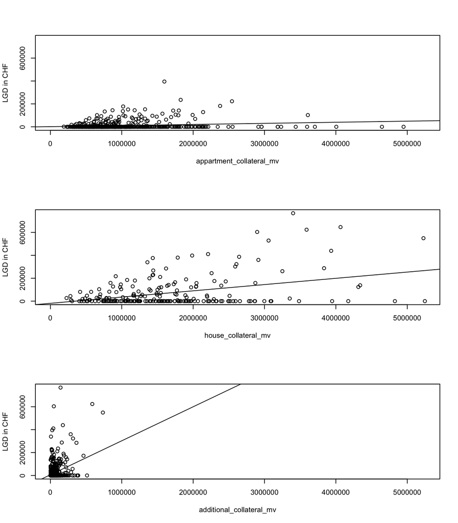

### Model 1

The first model uses the corresponding market values and a dummy whether the real estate type is single family house (1) or not (0):

$$\text{nominal LGD}_i = \beta_0 + \beta_1*\text{MV appartment}_i +
\beta_2*\text{MV house}_i + \beta_3*\text{MV additional}_i +
\beta_4*\text{single family house}_i + \epsilon_i$$

Summary of this model:

|  | *Dependent variable:* |
| --- | --- |
|  | regressors |
| loan_amount | 0.226*** |
|  | (0.051) |
| appartment_collateral_mv | -0.167*** |
|  | (0.040) |
| house_collateral_mv | -0.125*** |
|  | (0.040) |
| additional_collateral_mv | -0.094* |
|  | (0.052) |
| single_family_house | -18,369.900* |
|  | (10,850.470) |
| Constant | -2,179.528 |
|  | (5,352.111) |
| Observations | 842 |
| R<sup>2</sup> | 0.253 |
| Adjusted R<sup>2</sup> | 0.249 |
| Residual Std. Error | 68,128.230 (df = 836) |
| F Statistic | 56.745*** (df = 5; 836) |
| *Note:* | p<0.1; p<0.05; p<0.01 |

Following plot shows the difference between the realized LGD values and the corresponding predictions:

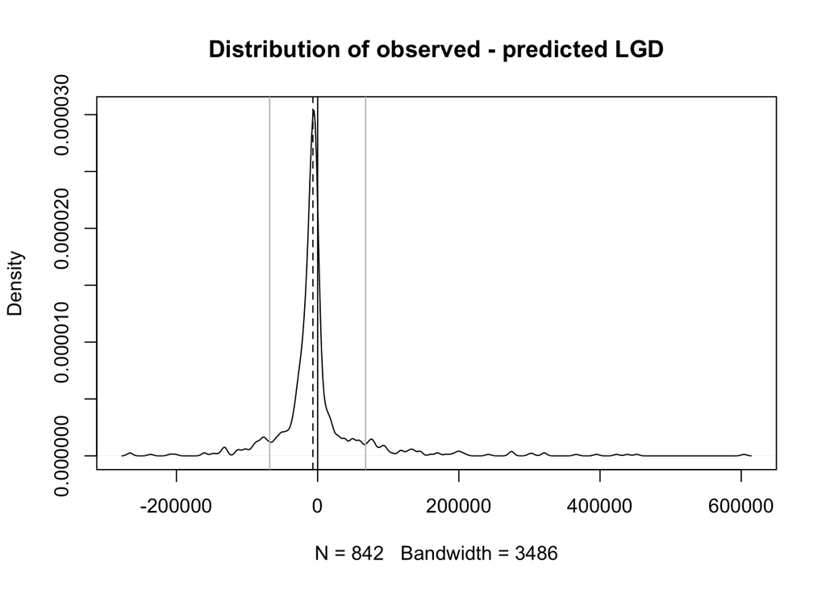

### todo private

also implement segm acc to ratio

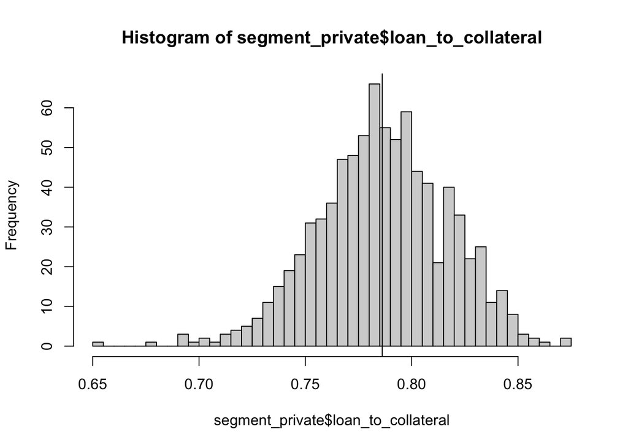

## Segment 2: Corporate Clients

First, note that the only real estate type of corporate clients is office building. Therefore, the positions only vary in loan amount, the market value of the collateral and whether the client provides additional collateral. Therefore, we need further logic to segment corporate clients more granular.

Looking at the ratio $\frac{\text{loan amount}}{\text{collateral}}$, we can see that not all clients must provide proportionally the same value of collateral.

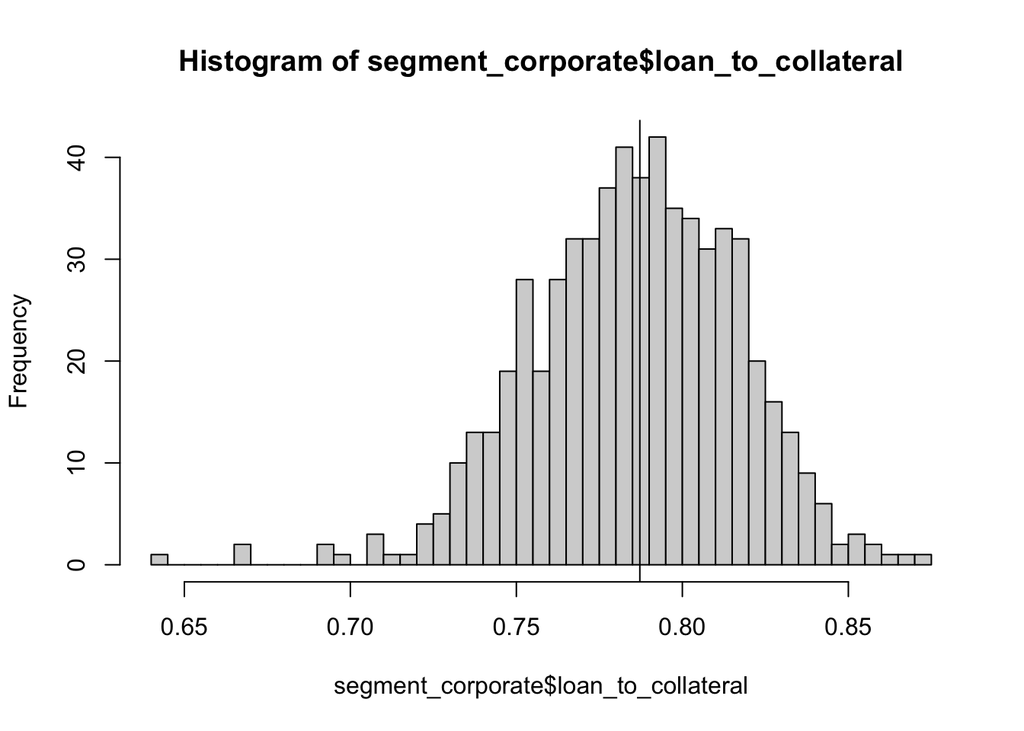

Economic intuition: due to client specific factors, there could be higher or lower risk associated with the position, allowing for lower collateral provided.

Given this logic, there should be a positive relationship between loan to collateral ratio and loss given default:

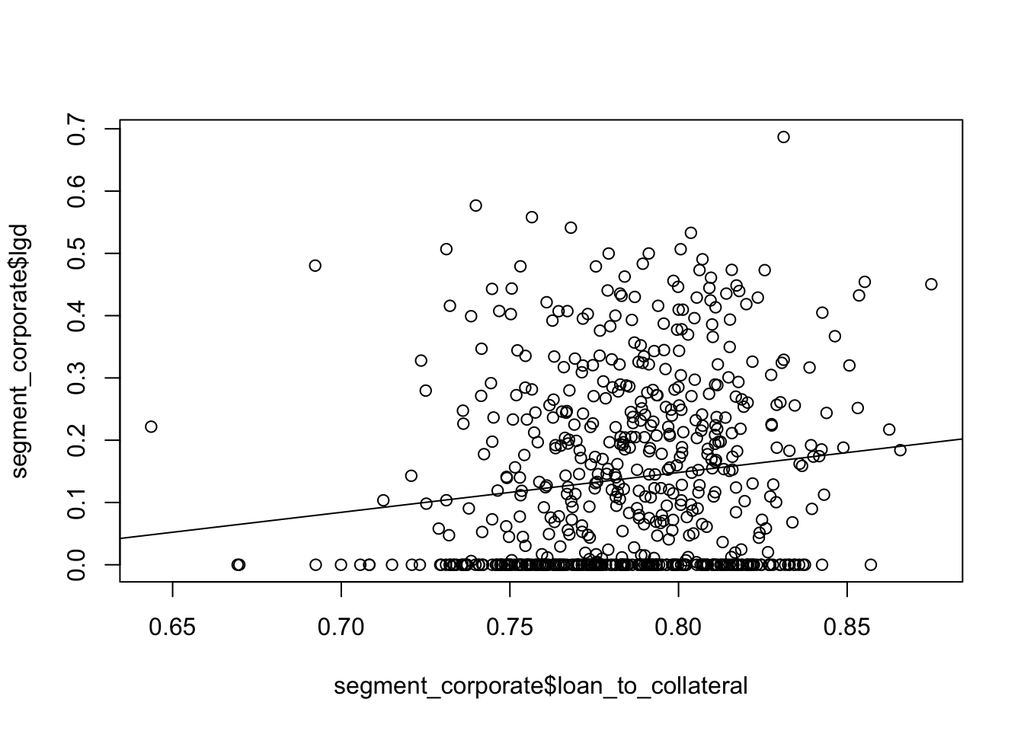

9.78% is the average LGD for low risk clients, 14.12% for medium risk clients and 18.91% for high risk clients.

*todo: maybe also make same for loan amount?* see model 4

### Model 1

|  | *Dependent variable:* |
| --- | --- |
|  | regressors |
| loan_amount | 1.706*** |
|  | (0.151) |
| office_collateral_mv | -1.222*** |
|  | (0.117) |
| additional_collateral_mv | -1.369*** |
|  | (0.156) |
| Constant | 72,141.380 |
|  | (147,286.300) |
| Observations | 611 |
| R<sup>2</sup> | 0.414 |
| Adjusted R<sup>2</sup> | 0.411 |
| Residual Std. Error | 2,731,748.000 (df = 607) |
| F Statistic | 142.655*** (df = 3; 607) |
| *Note:* | p<0.1; p<0.05; p<0.01 |

```
## [1] 0.1582634
```

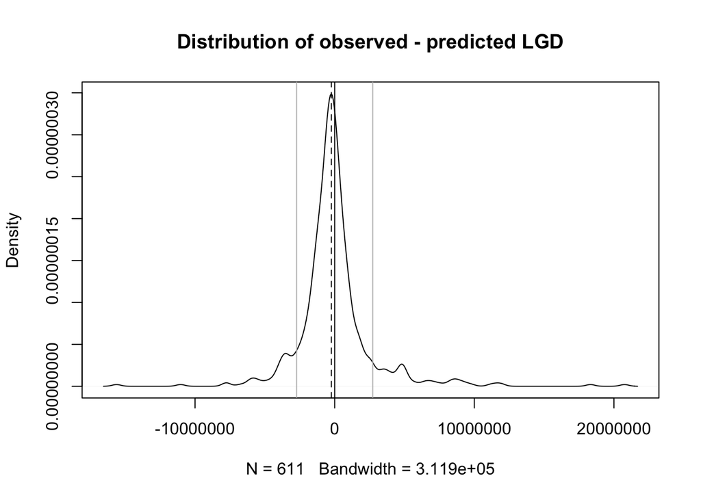

### Model 2

```
##
## Call:
## lm(formula = reformulate(regressors, dependent_variable), data = data)
##
## Residuals:
##      Min       1Q   Median       3Q      Max
## -0.18465 -0.12691 -0.03866  0.09584  0.51874
##
## Coefficients:
##                    Estimate Std. Error t value Pr(>|t|)
## (Intercept)         -0.3636     0.1522  -2.389  0.01718 *
## loan_to_collateral   0.6397     0.1936   3.304  0.00101 **
## ---
## Signif. codes:  0 '***' 0.001 '**' 0.01 '*' 0.05 '.' 0.1 ' ' 1
##
## Residual standard error: 0.1484 on 609 degrees of freedom
## Multiple R-squared:  0.01761,    Adjusted R-squared:  0.016
## F-statistic: 10.92 on 1 and 609 DF,  p-value: 0.001008
```

```
## [1] 0.1484393
```

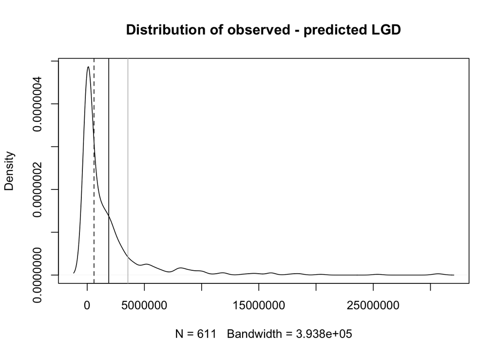

Problem: a lot of cases where observed way higher than predicted!

### Model 3

```
##
## Call:
## lm(formula = reformulate(regressors, dependent_variable), data = data)
##
## Residuals:
##      Min       1Q   Median       3Q      Max
## -0.18796 -0.12687 -0.03173  0.09724  0.50694
##
## Coefficients:
##                             Estimate Std. Error t value Pr(>|t|)
## (Intercept)                  -1.4743     4.4002  -0.335    0.738
## loan_to_collateral            1.3442     2.8354   0.474    0.636
## office_collateral_ratio       0.4463     1.7056   0.262    0.794
## additional_collateral_ratio   0.2245     1.7204   0.131    0.896
##
## Residual standard error: 0.148 on 607 degrees of freedom
## Multiple R-squared:  0.026,  Adjusted R-squared:  0.02118
## F-statistic: 5.401 on 3 and 607 DF,  p-value: 0.001133
```

```
## [1] 0.1488341
```

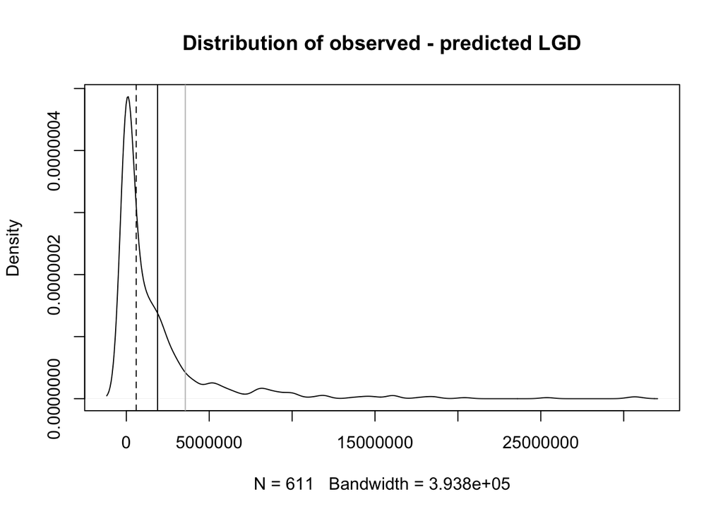

### Model 4

```
##
## Call:
## lm(formula = reformulate(regressors, dependent_variable), data = data)
##
## Residuals:
##       Min        1Q    Median        3Q       Max
## -11935744  -3881261   -724565   3013177  18993785
##
## Coefficients:
##                              Estimate   Std. Error t value    Pr(>|t|)
## (Intercept)              3018068.3764 1854472.9366   1.627       0.109
## loan_amount                    2.5228       0.4443   5.678 0.000000460 ***
## office_collateral_mv          -1.8963       0.3429  -5.531 0.000000798 ***
## additional_collateral_mv      -2.0244       0.4571  -4.429 0.000042479 ***
## ---
## Signif. codes:  0 '***' 0.001 '**' 0.01 '*' 0.05 '.' 0.1 ' ' 1
##
## Residual standard error: 6338000 on 58 degrees of freedom
## Multiple R-squared:  0.3779, Adjusted R-squared:  0.3457
## F-statistic: 11.75 on 3 and 58 DF,  p-value: 0.000004083
```

```
## [1] 0.1286378
```

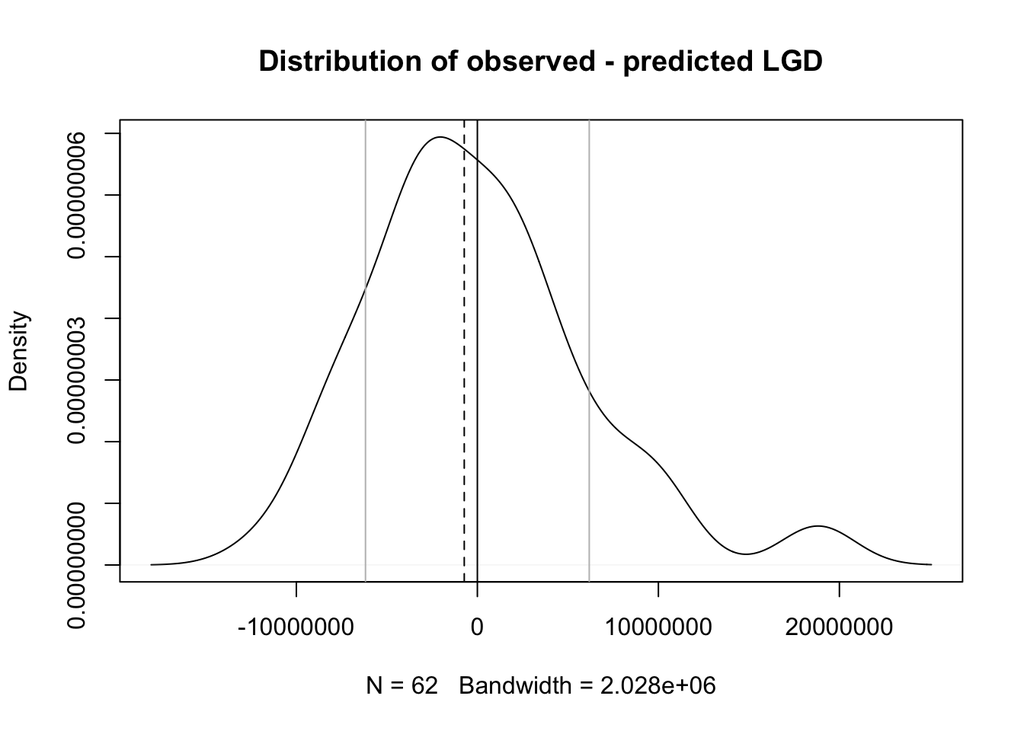

```
##
## Call:
## lm(formula = reformulate(regressors, dependent_variable), data = data)
##
## Residuals:
##      Min       1Q   Median       3Q      Max
## -4153632 -2431734 -1168088  1881684  8834706
##
## Coefficients:
##                                Estimate     Std. Error t value Pr(>|t|)
## (Intercept)              -1255297.98342  2100441.77650  -0.598    0.552
## loan_amount                     0.17126        0.39274   0.436    0.664
## office_collateral_mv            0.02316        0.30474   0.076    0.940
## additional_collateral_mv       -0.18991        0.40531  -0.469    0.641
##
## Residual standard error: 3300000 on 87 degrees of freedom
## Multiple R-squared:  0.04684,    Adjusted R-squared:  0.01397
## F-statistic: 1.425 on 3 and 87 DF,  p-value: 0.2409
```

```
## [1] 0.1565977
```

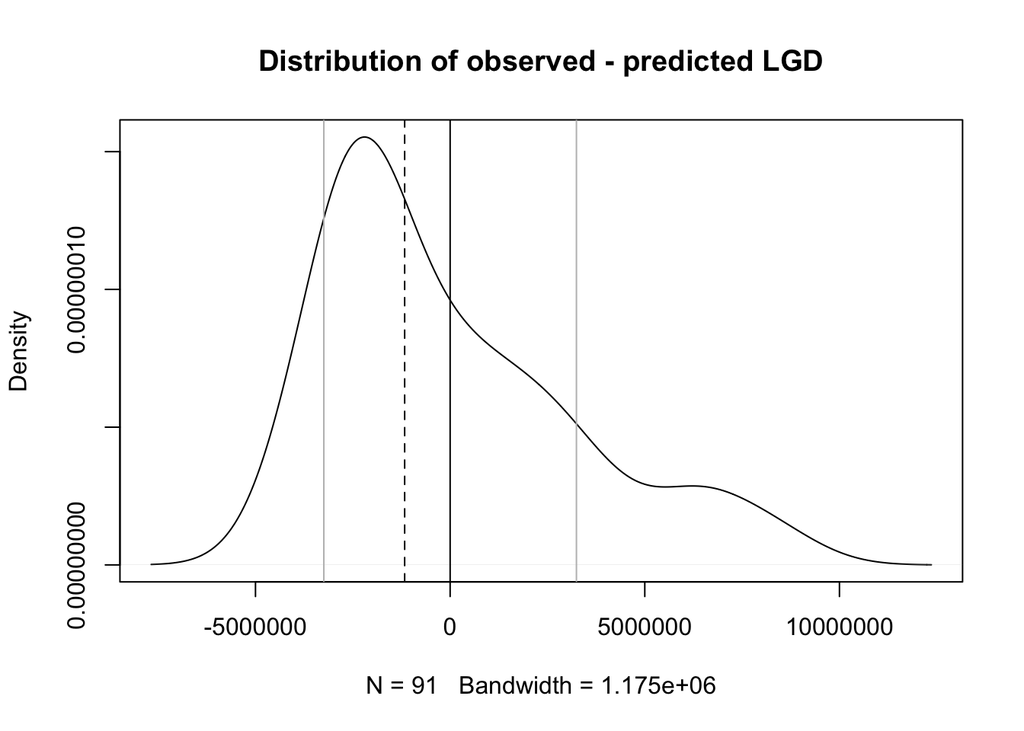

```
##
## Call:
## lm(formula = reformulate(regressors, dependent_variable), data = data)
##
## Residuals:
##      Min       1Q   Median       3Q      Max
## -2692952  -731821  -125460   582812  5973902
##
## Coefficients:
##                              Estimate   Std. Error t value Pr(>|t|)
## (Intercept)              -57557.43828 114372.20674  -0.503   0.6150
## loan_amount                   0.15704      0.17534   0.896   0.3709
## office_collateral_mv          0.01297      0.13670   0.095   0.9245
## additional_collateral_mv     -0.41101      0.17328  -2.372   0.0181 *
## ---
## Signif. codes:  0 '***' 0.001 '**' 0.01 '*' 0.05 '.' 0.1 ' ' 1
##
## Residual standard error: 1207000 on 454 degrees of freedom
## Multiple R-squared:  0.2261, Adjusted R-squared:  0.221
## F-statistic: 44.21 on 3 and 454 DF,  p-value: < 0.00000000000000022
```

```
## [1] 0.1503835
```

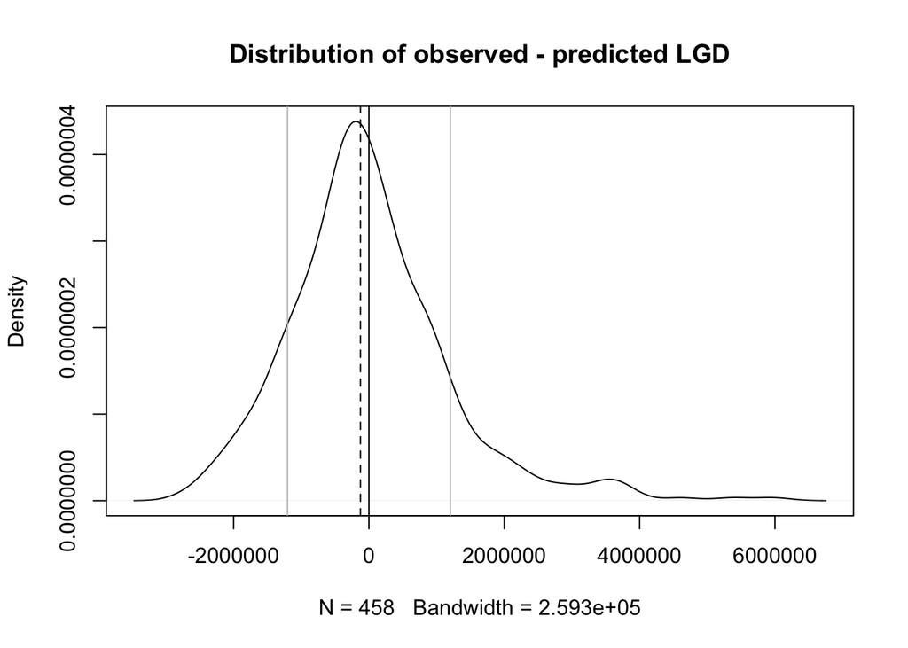

### Model 4

```
## [1] 98
```

```
## [1] 418
```

```
## [1] 95
```

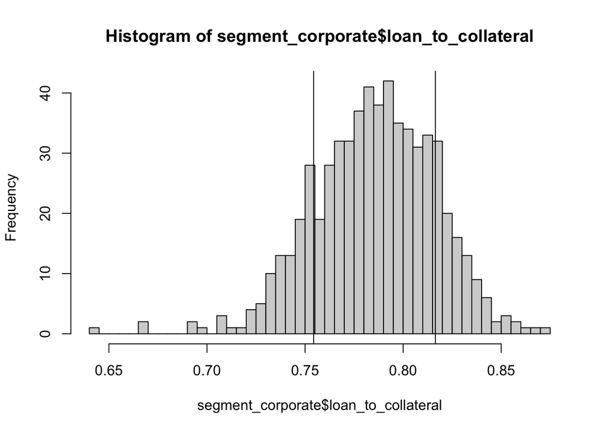

```
##
## Call:
## lm(formula = reformulate(regressors, dependent_variable), data = data)
##
## Residuals:
##      Min       1Q   Median       3Q      Max
## -6748572  -667852   221447   840999  6984018
##
## Coefficients:
##                              Estimate   Std. Error t value Pr(>|t|)
## (Intercept)              -646387.2240  283041.0449  -2.284   0.0247 *
## loan_amount                    0.4975       1.2268   0.406   0.6861
## office_collateral_mv          -0.2078       1.0086  -0.206   0.8373
## additional_collateral_mv      -1.0614       1.1861  -0.895   0.3733
## ---
## Signif. codes:  0 '***' 0.001 '**' 0.01 '*' 0.05 '.' 0.1 ' ' 1
##
## Residual standard error: 1990000 on 91 degrees of freedom
## Multiple R-squared:  0.7433, Adjusted R-squared:  0.7348
## F-statistic: 87.83 on 3 and 91 DF,  p-value: < 0.00000000000000022
```

```
## [1] 0.232092
```

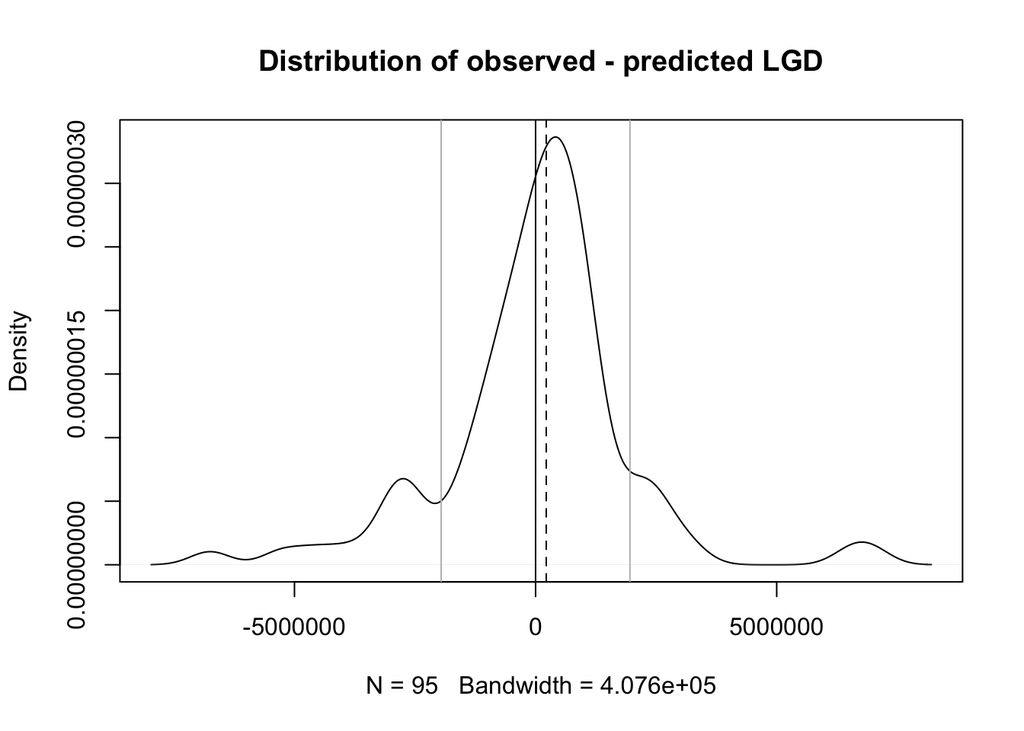

```
##
## Call:
## lm(formula = reformulate(regressors, dependent_variable), data = data)
##
## Residuals:
##       Min        1Q    Median        3Q       Max
## -14766729   -958151   -180448    676154  19011234
##
## Coefficients:
##                             Estimate  Std. Error t value          Pr(>|t|)
## (Intercept)              -55152.3550 187763.9106  -0.294             0.769
## loan_amount                   2.7166      0.3636   7.471 0.000000000000476 ***
## office_collateral_mv         -2.0012      0.2856  -7.006 0.000000000010005 ***
## additional_collateral_mv     -2.2572      0.3062  -7.371 0.000000000000926 ***
## ---
## Signif. codes:  0 '***' 0.001 '**' 0.01 '*' 0.05 '.' 0.1 ' ' 1
##
## Residual standard error: 2804000 on 414 degrees of freedom
## Multiple R-squared:  0.429,  Adjusted R-squared:  0.4248
## F-statistic: 103.7 on 3 and 414 DF,  p-value: < 0.00000000000000022
```

```
## [1] 0.1532365
```

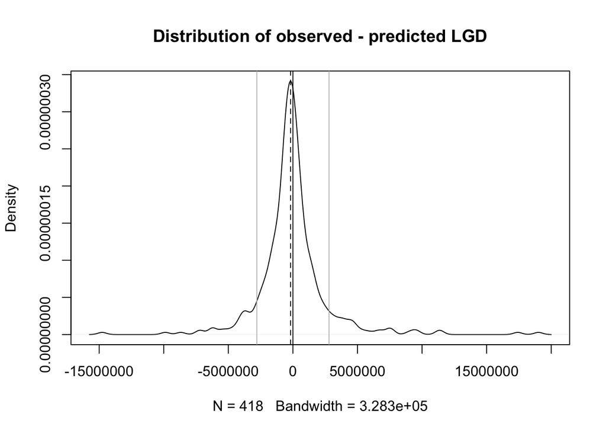

```
##
## Call:
## lm(formula = reformulate(regressors, dependent_variable), data = data)
##
## Residuals:
##      Min       1Q   Median       3Q      Max
## -3999076 -1245613  -875950    54113 10544572
##
## Coefficients:
##                              Estimate   Std. Error t value Pr(>|t|)
## (Intercept)              1065542.4459  326731.7308   3.261  0.00155 **
## loan_amount                   -0.5902       0.5159  -1.144  0.25551
## office_collateral_mv           0.4539       0.3839   1.182  0.24008
## additional_collateral_mv       0.1962       0.4062   0.483  0.63018
## ---
## Signif. codes:  0 '***' 0.001 '**' 0.01 '*' 0.05 '.' 0.1 ' ' 1
##
## Residual standard error: 2411000 on 94 degrees of freedom
## Multiple R-squared:  0.04529,    Adjusted R-squared:  0.01482
## F-statistic: 1.486 on 3 and 94 DF,  p-value: 0.2233
```

```
## [1] 0.2773083
```

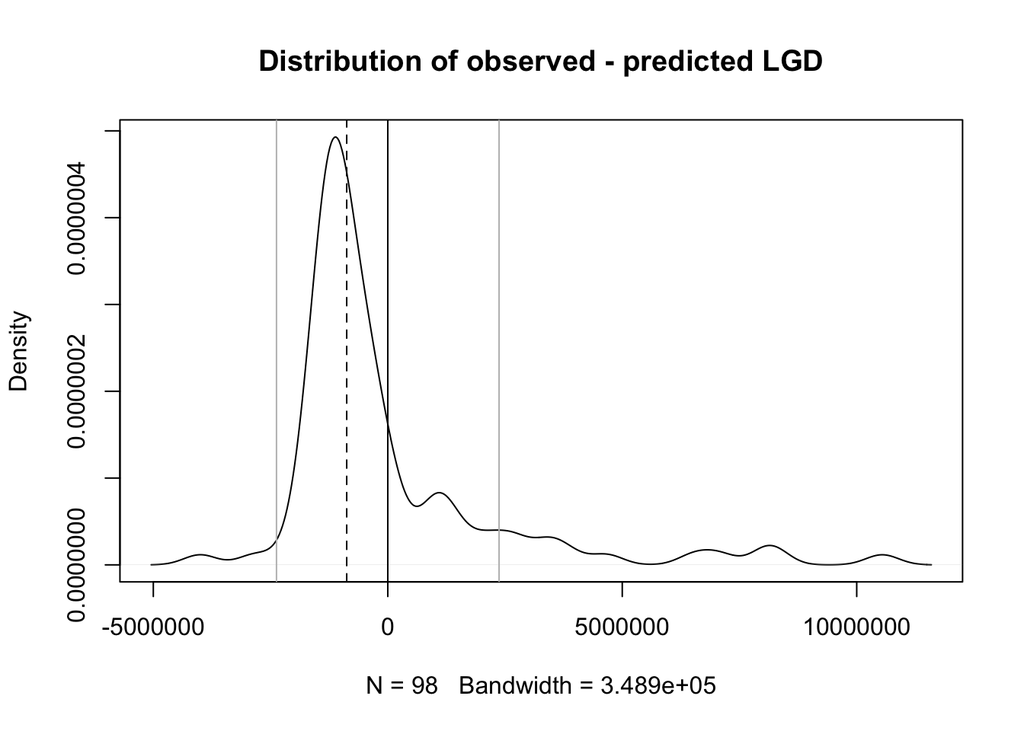

```
## [1] 2610072
```

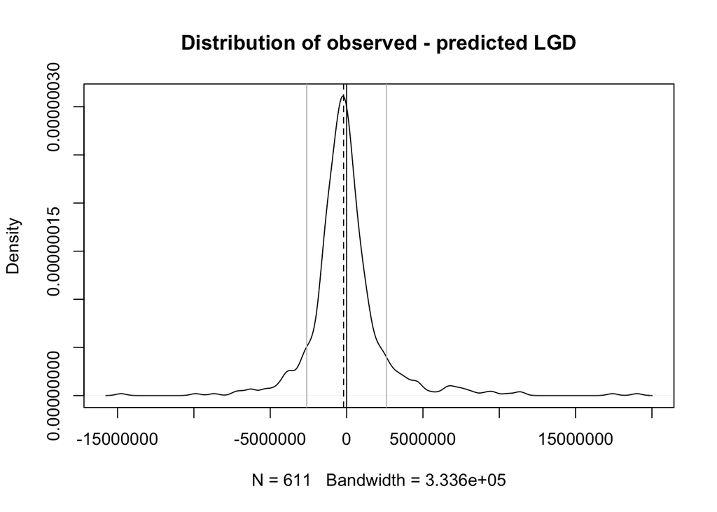